# 20171105

zhangbei

Setting global option to turn warnings off

```r
knitr::opts_chunk$set(warning=FALSE)
```

# Read load the data

```r
data<-read.table(unzip(".\\repdata%2Fdata%2Factivity.zip"),header=TRUE,sep=",",fill=TRUE,na.strings = "NA")
names(data)
```

```
## [1] "steps"    "date"     "interval"
```

```r
dim(data)
```

```
## [1] 17568     3
```

```r
str(data)
```

```
## 'data.frame':    17568 obs. of  3 variables:
##  $ steps   : int  NA NA NA NA NA NA NA NA NA NA ...
##  $ date    : Factor w/ 61 levels "2012-10-01","2012-10-02",..: 1 1 1 1 1 1 1 1 1 1 ...
##  $ interval: int  0 5 10 15 20 25 30 35 40 45 ...
```

```r
summary(data)
```

```
##      steps                date          interval
##  Min.   :  0.00   2012-10-01:  288   Min.   :   0.0
##  1st Qu.:  0.00   2012-10-02:  288   1st Qu.: 588.8
##  Median :  0.00   2012-10-03:  288   Median :1177.5
##  Mean   : 37.38   2012-10-04:  288   Mean   :1177.5
##  3rd Qu.: 12.00   2012-10-05:  288   3rd Qu.:1766.2
##  Max.   :806.00   2012-10-06:  288   Max.   :2355.0
##  NA's   :2304     (Other)   :15840
```

```r
head(data)
```

```
##   steps       date interval
## 1    NA 2012-10-01        0
## 2    NA 2012-10-01        5
## 3    NA 2012-10-01       10
## 4    NA 2012-10-01       15
## 5    NA 2012-10-01       20
## 6    NA 2012-10-01       25
```

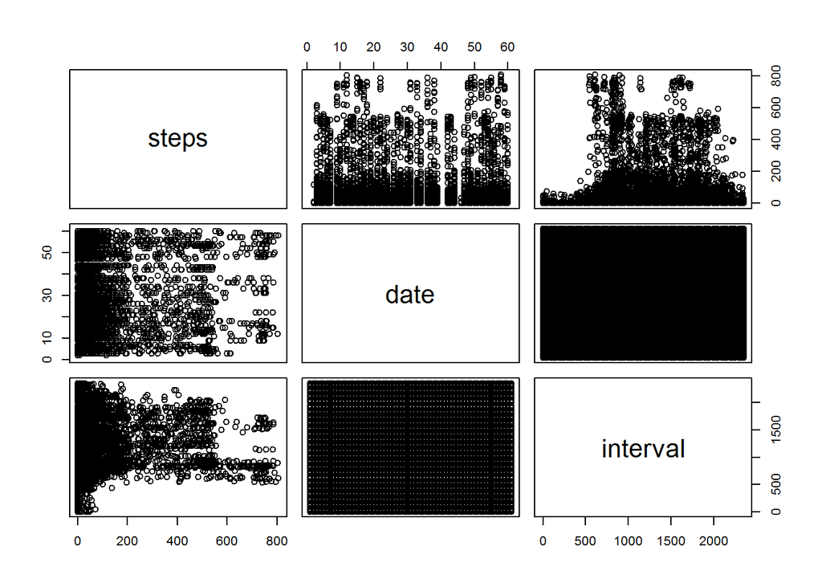

```r
pairs(data)
```

# What is mean total number of steps taken per day?

1. Calculate the total number of steps taken per day

```r
Stepsday<- aggregate(steps ~ date, data, sum, na.rm=TRUE)
```

2.If you do not understand the difference between a histogram and a barplot, research the difference between them. Make a histogram of the total number of steps taken each day

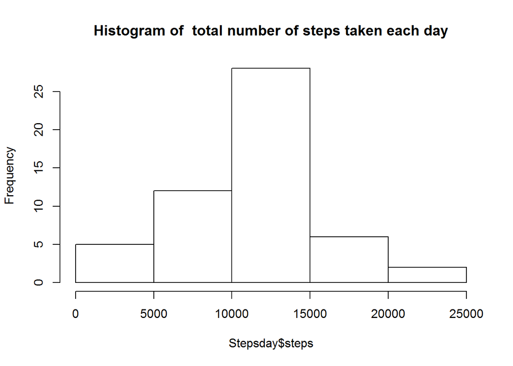

```r
hist(Stepsday$steps,main="Histogram of  total number of steps taken each day")
```

3.mean and median of the total number of steps taken per day mean total number of steps taken each day is

```r
mean(Stepsday$steps)
```

```
## [1] 10766.19
```

The median total number of steps taken each day is

```r
median(Stepsday$steps)
```

```
## [1] 10765
```

# What is the average daily activity pattern?

1. Make a time series plot (i.e. type = “l”) of the 5-minute interval (x-axis) and the average number of steps taken, averaged across all days (y-axis)

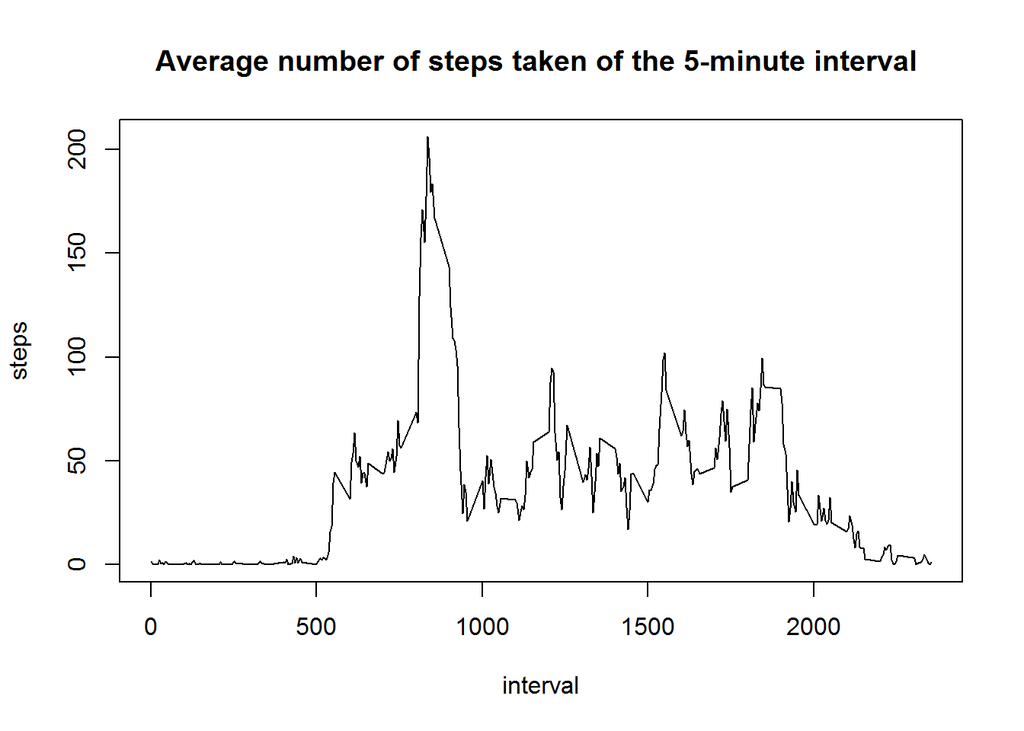

```r
Stepsinterval<-aggregate(steps~interval, data=data, mean, na.rm=TRUE)
plot(steps~interval, data=Stepsinterval, type="l",main="Average number of steps taken of the 5-minute interval ")
```

2.calculate Which 5-minute interval, on average across all the days in the dataset, contains the maximum number of steps

```r
Stepsinterval[which.max(Stepsinterval$steps),]$interval
```

```
## [1] 835
```

# Imputing missing values

1.Calculate and report the total number of missing values in the dataset

```r
sum(!complete.cases(data))
```

```
## [1] 2304
```

2.Devise a strategy for filling in all of the missing values in the dataset. The strategy does not need to be sophisticated. For example, you could use the mean/median for that day, or the mean for that 5-minute interval, etc.

3.Create a new dataset that is equal to the original dataset but with the missing data filled in.

```r
datafillna<-data
for(i in 1:nrow(datafillna))
{ if (is.na(datafillna$steps[i]))
  datafillna$steps[i]<-Stepsinterval$steps[i]
}
```

4.Make a histogram of the total number of steps taken each day and Calculate and report the mean and median total number of steps taken per day. Do these values differ from the estimates from the first part of the assignment? What is the impact of imputing missing data on the estimates of the total daily number of steps?

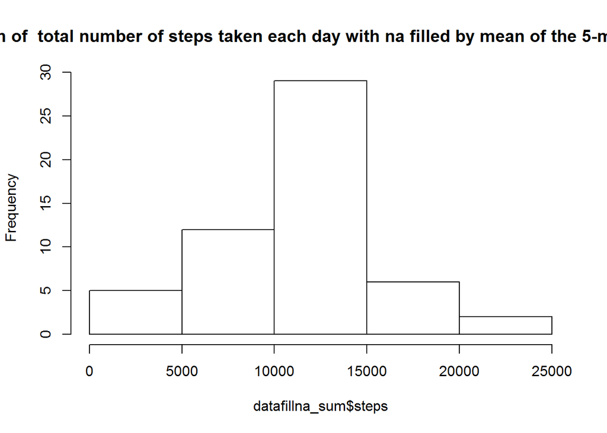

```r
datafillna_sum<-aggregate(steps ~ date, data=datafillna, FUN = "sum")
hist(datafillna_sum$steps,main="Histogram of  total number of steps taken each day with na filled by mean of the 5-minute interval")
```

Here is the mean of the total number of steps taken per day:

```r
mean(datafillna_sum$steps)
```

```
## [1] 10766.19
```

Here is the median of the total number of steps taken per day:

```r
median(datafillna_sum$steps)
```

```
## [1] 10765.59
```

The mean didn’t change after the replacements of NAs, the median changed.

# Are there differences in activity patterns between weekdays and weekends?

1.Create a new factor variable in the dataset with two levels – “weekday” and “weekend” indicating whether a given date is a weekday or weekend day.

```r
Sys.setlocale("LC_TIME", "English")
```

```
## [1] "English_United States.1252"
```

```r
data$day<-weekdays(as.Date(data$date))
data$day<-as.factor(data$day)

levels(data$day)[levels(data$day) %in% c("Monday","Tuesday","Wednesday","Thursday","Friday" )] <- "weekday"
levels(data$day)[levels(data$day) %in% c("Saturday","Sunday")] <- "weekend"
```

2.Make a panel plot containing a time series plot (i.e. type = “l”) of the 5-minute interval (x-axis) and the average number of steps taken, averaged across all weekday days or weekend days (y-axis).

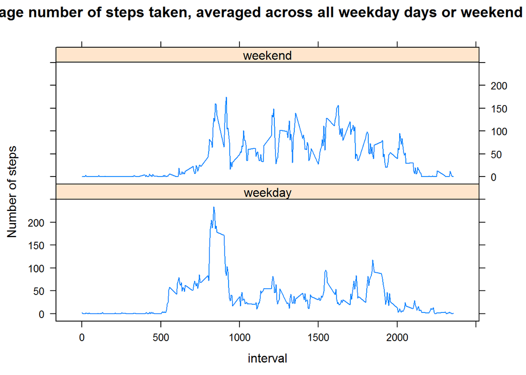

```r
datadayinterval <- aggregate(steps ~ interval+day, data, mean,na.rm=TRUE)
library("lattice")
xyplot(steps~interval|day,data=datadayinterval,type="l",layout=c(1,2),xlab="interval",ylab="Number of steps",main="Average number of steps taken, averaged across all weekday days or weekend days")
```

The average steps over the weekends show higher pattern than that of the weekdays